# Axon guidance molecule expression in developing SC

James Choi

Last compiled:2022-04-01

## Background

Superior colliculus is innervated by RGC axons during the early post-natal period i.e. between E19 and P8. Innervation by these projections have previously been described to be sequential - different anatomical areas of SC are innervated at different time (e.g. anterior vs posterior).

Hypothesis: Cells of SC express axon guidance molecules in time-dependent manner that coincides with RGC projection innervation.

```r
results_out <- "results/guidance-molecules/"
dir.create(path = results_out)
```

## Cells of developing superior colliculus

```r
library(Seurat)
library(ggplot2)
library(dplyr)
library(KEGGREST)
```

```r
sc <- readRDS(file = "data/allages_dims20_res0.3_final.rds")
# There are excluded cells
sc$celltype <- Idents(sc)
sc <- sc[, sc$celltype != "Excluded"]
# tmp <- readRDS(file = 'data/SC_20200103.rds')
```

Analysis done by Ana.

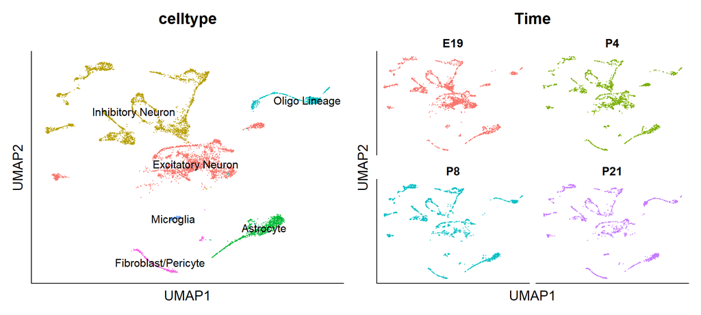

```r
sc$celltype <- factor(x = sc$celltype, levels = c("Excitatory Neuron", "Inhibitory Neuron",
    "Astrocyte", "Oligo Lineage", "Microglia", "Fibroblast/Pericyte"))
sc$Time <- factor(x = sc$Time, levels = c("E19", "P4", "P8", "P21"))
p1 <- DimPlot(sc, label = TRUE, group.by = "celltype") + xlab(label = "UMAP1") +
    ylab(label = "UMAP2") + theme(axis.text = element_blank(), axis.ticks = element_blank(),
    legend.position = "none")
p2 <- DimPlot(sc, group.by = "Time", split.by = "Time", ncol = 2) + xlab(label = "UMAP1") +
    ylab(label = "UMAP2") + theme(axis.text = element_blank(), axis.ticks = element_blank(),
    legend.position = "none")
(p1 | p2) + patchwork::plot_layout()
```

## Guidance molecules - all cell-types

First we query expression of the axon guidance molecules in all cell-types.

### GeneCopoeia ExProfile Array

From https://www.genecopoeia.com/product/pathway-gene-qpcr-arrays/

Gene list #013 (QG013): ExProfile™ Human Extracellular Matrix and Adhesion Molecules Related Gene qPCR Array

```r
# This was written manually because reading the PDF was a pain.
qg.genes <- c("SPG7", "FN1", "CD44", "HPRT1", "VTN", "VCAM1", "TNC", "CLEC3B", "TIMP3",
    "TIMP2", "TIMP1", "THBS3", "THBS2", "THBS1", "TGFBI", "SPP1", "SPG7", "SPARC",
    "SGCE", "SELP", "SELL", "SELE", "PECAM1", "MMP9", "MMP8", "MMP7", "MMP3", "MMP16",
    "MMP15", "MMP14", "MMP13", "MMP12", "MMP11", "MMP10", "MMP1", "LAMB1", "LAMA3",
    "LAMA2", "LAMA1", "KAL1", "ITGB5", "ITGB3", "ITGB3", "ITGB2", "ITGB1", "ITGAV",
    "ITGAM", "ITGAL", "ITGA8", "ITGA7", "ITGA6", "ITGA5", "ITGA4", "ITGA2", "ITGA1",
    "ICAM1", "CTNND1", "CTNNB1", "CTNNA1", "CTGF", "VCAN", "COL8A1", "COL6A2", "COL6A1",
    "COL5A1", "COL4A2", "COL1A1", "COL16A1", "COL15A1", "COL14A1", "COL12A1", "COL11A1",
    "CNTN1", "ADAMTS8", "ADAMTS1", "COL7A1", "COL12A1", "CDH1", "ECM1", "HAS1", "ITGA3",
    "GAPDH", "ACTB", "B2M", "RPL13A", "HPRT1", "RN18S1")
# Mouse ortholog name conversion
qg.genes <- plyr::mapvalues(x = qg.genes, from = c("HPRT1", "MMP1"), to = c("HPRT",
    "MMP1B"))
qg.genes <- unique(tools::toTitleCase(text = tolower(qg.genes)))
qg.genes.missing <- qg.genes[!qg.genes %in% rownames(sc)]
qg.genes <- qg.genes[qg.genes %in% rownames(sc)]
```

### KEGG pathway

```r
kegg.guidance.entry <- keggGet(dbentries = "mmu04360")
kegg.guidance.genes <- kegg.guidance.entry[[1]]$GENE[seq(0, length(kegg.guidance.entry[[1]]$GENE),
    2)]
kegg.guidance.genes <- gsub("\\;.*", "", kegg.guidance.genes)
kegg.guidance.genes.missing <- kegg.guidance.genes[!kegg.guidance.genes %in% rownames(sc)]
kegg.guidance.genes <- kegg.guidance.genes[kegg.guidance.genes %in% rownames(sc)]
```